# Lab 2

Robert Cervantes

2025-09-05

# Tasks

These are the tasks for lab 2

## Task 1

Obtain the working directory

```r
getwd()
```

```
## [1] "/Users/robertcervantes/Documents/Labs (4753)/Lab 2"
```

## Task 2

Read in csv data

```r
csv <- read.csv("EPAGAS.csv")
```

Show the first 6 rows of data

```r
head(csv)
```

```
##    MPG
## 1 36.3
## 2 41.0
## 3 36.9
## 4 37.1
## 5 44.9
## 6 36.8
```

## Task 3

Create a mpg vector from the MPG column of the CSV file

```r
mpg <- csv$MPG
mpg
```

```
##   [1] 36.3 41.0 36.9 37.1 44.9 36.8 30.0 37.2 42.1 36.7 32.7 37.3 41.2 36.6 32.9
##  [16] 36.5 33.2 37.4 37.5 33.6 40.5 36.5 37.6 33.9 40.2 36.4 37.7 37.7 40.0 34.2
##  [31] 36.2 37.9 36.0 37.9 35.9 38.2 38.3 35.7 35.6 35.1 38.5 39.0 35.5 34.8 38.6
##  [46] 39.4 35.3 34.4 38.8 39.7 36.3 36.8 32.5 36.4 40.5 36.6 36.1 38.2 38.4 39.3
##  [61] 41.0 31.8 37.3 33.1 37.0 37.6 37.0 38.7 39.0 35.8 37.0 37.2 40.7 37.4 37.1
##  [76] 37.8 35.9 35.6 36.7 34.5 37.1 40.3 36.7 37.0 33.9 40.1 38.0 35.2 34.8 39.5
##  [91] 39.9 36.9 32.9 33.8 39.8 34.0 36.8 35.0 38.1 36.9
```

Standardize mpg and verify result

```r
z <- (csv$MPG - mean(csv$MPG)) / sd(csv$MPG)
```

```r
mean(z)
```

```
## [1] 7.931156e-17
```

```r
var(z)
```

```
## [1] 1
```

Find mpg values that are possible outliers

```r
# possible outliers
mpg[abs(z) >= 2 & abs(z) < 3]
```

```
## [1] 30.0 42.1 31.8
```

values of mpg that defined as outliers.

```r
mpg[abs(z) > 3]
```

```
## [1] 44.9
```

Creating dotplot of MPG

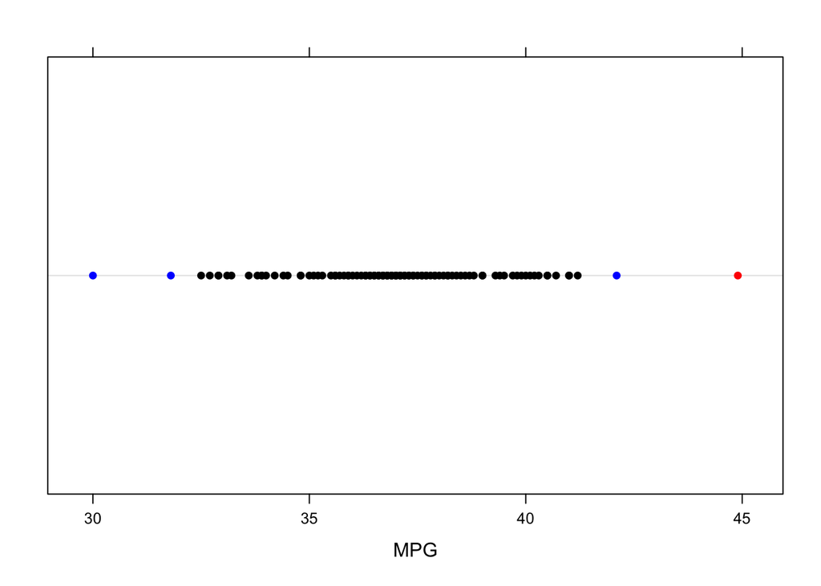

```r
## first loading package in
library(lattice)


colors <- rep("black", length(z))
colors[abs(z) >= 2 & abs(z) <= 3] <- "blue" # possible outliers
colors[abs(z) > 3] <- "red" # outliers

# construct dotplot
dotplot(mpg,
        col = colors,
        xlab = "MPG")
```

## Task 4

Make a boxplot of mpg variable

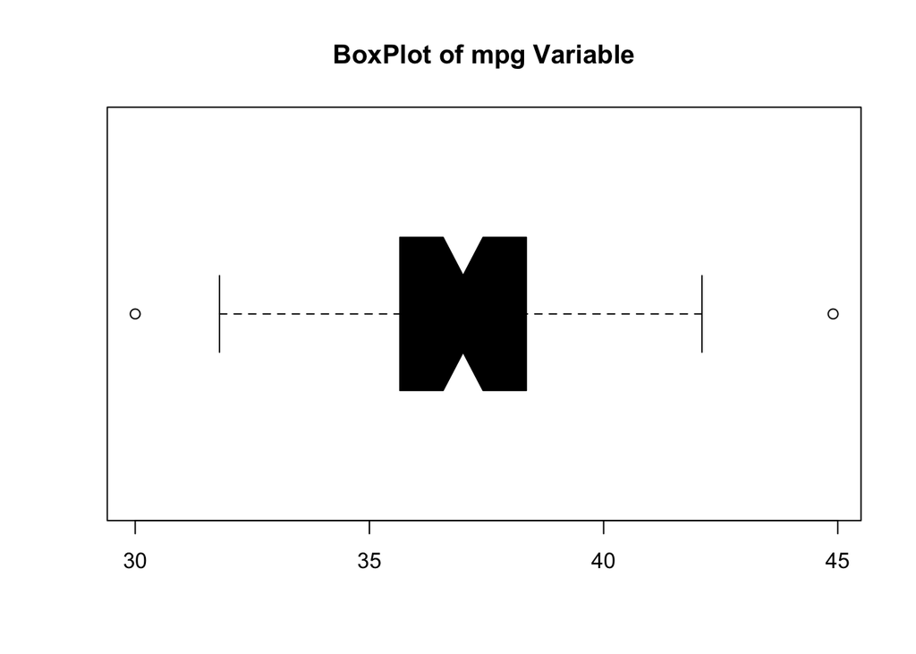

```r
boxplot(mpg,
        col = "black",
        notch = TRUE,
        main = "BoxPlot of mpg Variable",
        horizontal = TRUE
        )
```

Using the Chebyshev’s theorem
$$1 - \frac{1}{k^2}$$

Where $k$ is the standard deviation of the mean and $k > 1$.

Predicting proportion within 2 STDev of the mean of the data set.

$$1 - \frac{1}{k^2} = 1 - \frac{1}{2^2} = 1 - \frac{1}{4} = \frac{3}{4}
\approx 0.75$$

So using the exact proportion with the MPG data 96% fall within 2 STDev. :

```r
length(mpg[abs(z) < 2]) / length(mpg)
```

```
## [1] 0.96
```

The Chebyshev’s theorem does agree with the data because the theorom states that prorption of the data must be at least 75% and the I got 96%.

Using Empirical rule which is also known as the 68-95-99.7 Rule. We know that for normal distribution about 95% of data should fall within 2 STDev of the mean.

In the MPG data the the exact proportion was 96% which is very close to 95% so by the Empirical rule the data corresponds very well!

The Empirical rule is valid in this case because the data is “Normal” as shown by the close match between the predicted 95% and the actual 96% proportions.